# AI Engineering - Chapter 1 Notes

**Chapter:** Introduction to Building AI Applications with Foundation Models  
**Core question:** What changed after foundation models, and how should engineers think about building real AI applications instead of just demos?

**Chapter thesis:** Post-2020 AI is defined by **scale**. Larger models became more capable, but also too expensive for most teams to train. That combination created **model-as-a-service** and made **AI engineering** - building applications on top of readily available foundation models - one of the fastest-growing engineering disciplines.

## 1. Big picture: why AI engineering exists now

### Consequence 1: More capability

Scaling made models useful across more tasks: writing, coding, summarization, image generation, search-like aggregation, tutoring, workflow automation, and more.

### Consequence 2: Higher training barrier

Training frontier models requires huge data, compute, and specialized talent. Most teams cannot afford to train them from scratch.

### Result: Model-as-a-service

A few organizations train powerful models; everyone else builds applications on top of them through APIs, open-source weights, hosted services, and platforms.

**AI engineering** is not “AI research from scratch.” It is the engineering discipline of adapting, evaluating, deploying, and maintaining applications powered by foundation models. It inherits many lessons from ML engineering, but the availability of general-purpose models changes the workflow.

## 2. Language models, tokens, and generation

### 2.1 What a language model does

A language model encodes statistical information about language. Given a context, it estimates what token is likely to come next or what token should fill a missing spot. This makes a model feel like a **completion machine**: you give it a prompt, and it completes the sequence.

**Important mental model:** A model completion is a probabilistic prediction, not guaranteed truth. This is why foundation models can feel magical in one moment and frustrating in the next.

### 2.2 Tokens and tokenization

The basic unit of a language model is a **token**. A token can be a character, word, or word fragment. Tokenization is the process of converting raw text into these units. Models use tokens instead of raw words because tokens balance meaning, efficiency, and robustness to unknown words.

| Concept | Meaning | Why it matters |
| --- | --- | --- |
| **Token** | A model-readable piece of text such as a word, subword, punctuation mark, or special marker. | Cost, context length, speed, and model behavior are often measured in tokens. |
| **Vocabulary** | The complete set of tokens a model can represent. | A larger vocabulary can represent more units directly but affects model size and efficiency. |
| **Special tokens** | Markers like beginning-of-sequence and end-of-sequence. | They help the model understand sequence boundaries and when to stop generating. |

### 2.3 Two major language-model types

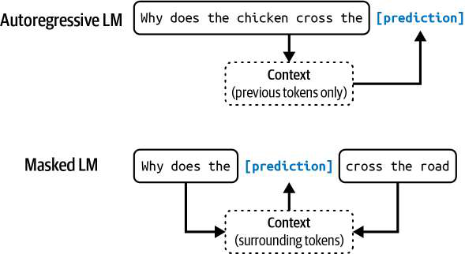

**Figure 1-2: Autoregressive vs. masked language models** - Autoregressive models predict next tokens from previous context; masked models fill blanks using surrounding context.

| Model type | Training objective | Uses | Key limitation |
| --- | --- | --- | --- |
| **Masked language model** | Predict missing tokens using context before and after the blank. | Classification, sentiment analysis, debugging-like tasks, context understanding. | Not naturally optimized for open-ended generation. |
| **Autoregressive language model** | Predict the next token using previous tokens only. | Chat, writing, code generation, summarization, open-ended generation. | Output is probabilistic and must be carefully evaluated. |

### 2.4 Why completion is powerful

Many tasks can be reframed as completion:

- **Translation:** “How are you in French is ...”
- **Classification:** “Question: Is this email spam? Answer: ...”
- **Summarization:** “Summarize the following document: ... Summary: ...”
- **Coding:** “Write a function that does X: ...”

However, raw completion is not the same as helpful conversation. Post-training and instruction-following are needed to make a model respond appropriately to user requests.

## 3. Self-supervision and why LLMs scaled

The key reason language models scaled so effectively is **self-supervision**. In supervised learning, humans label data. In self-supervised language modeling, the data itself creates the labels: each next token becomes the target answer for the previous context.

| Learning style | Labels? | Example | Scaling implication |
| --- | --- | --- | --- |
| **Supervised learning** | Human-provided labels | Images labeled as car, cat, dog, etc. | Powerful but expensive and slow to scale because labeling bottlenecks dominate. |
| **Self-supervised learning** | Labels inferred from input data | Sentence tokens create next-token prediction examples. | Scales well because text is abundant and does not need manual labels for every token. |
| **Unsupervised learning** | No labels | Clustering documents by topic. | Useful, but different from self-supervision. |

### Example: one sentence creates many training samples

For a sentence like `I love street food.`, the model can learn from multiple context -> next-token pairs: beginning marker -> “I”, then “I” -> “love”, then “I love” -> “street”, and so on. This turns ordinary text into massive training data.

### 3.1 Why larger models need more data

Model size is usually measured by number of **parameters**, which are values updated during training. Bigger models have more capacity, but that capacity is useful only when enough data exists to train them well. Training a large model on too little data wastes compute and can underperform smaller, better-matched models.

## 4. From LLMs to foundation models

Language models operate on text. Foundation models extend the idea to models that can support broader data modalities and a wider range of tasks. The chapter uses **foundation models** as an umbrella term for both large language models and large multimodal models.

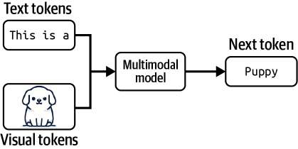

**Figure 1-3: Multimodal generation** - A multimodal model can condition generation on text and visual tokens together.

### 4.1 Multimodal models

A **multimodal model** works with more than one data modality, such as text, images, audio, video, 3D assets, or biological structures. A large multimodal model can generate open-ended outputs while conditioning on multiple types of input.

### 4.2 Natural language supervision and CLIP

The chapter uses CLIP as an example of scaling beyond manually labeled datasets. Instead of humans labeling each image, the model learns from image-text pairs that already co-occur online. This is a form of natural language supervision and helps explain why multimodal models can scale faster than classical labeled-image approaches.

### 4.3 General-purpose models vs. task-specific models

| Model style | Strength | Weakness | Typical engineering move |
| --- | --- | --- | --- |
| **Task-specific model** | Small, optimized, often faster and cheaper for one job. | Cannot easily generalize to new tasks. | Train or tune specifically for a business metric. |
| **Foundation model** | Broad capabilities across many tasks out of the box. | May be expensive, hard to evaluate, and not perfectly aligned to a specific product need. | Adapt with prompts, RAG, finetuning, tools, data, and evaluation. |

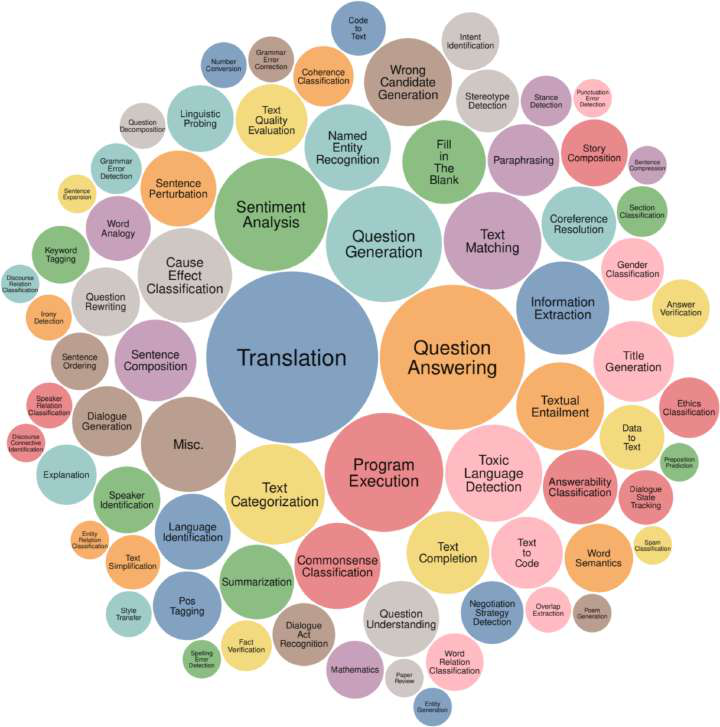

**Figure 1-4: Breadth of foundation-model tasks** - The Super-NaturalInstructions benchmark illustrates how broad general-purpose model tasks can be.

### 4.4 Three core adaptation techniques introduced

### Prompt engineering

Adapt behavior through instructions, examples, formatting constraints, and context. No model weights change.

### RAG

Retrieval-augmented generation connects the model to external knowledge sources so it can use relevant retrieved context.

### Finetuning

Further train the model on data for a task, style, domain, or behavior. Model weights change.

## 5. Why AI engineering took off

The chapter names three forces that created the conditions for AI engineering to grow rapidly.

| Force | What changed | Practical effect |
| --- | --- | --- |
| **General-purpose AI capabilities** | Foundation models can do many tasks, not just one narrow prediction problem. | More teams can imagine useful applications: support, coding, design, education, search, analytics, operations. |
| **Increased AI investment** | ChatGPT-like success made AI feel strategically urgent. | Companies and investors fund AI projects more aggressively. |
| **Developer ecosystem growth** | Open-source tools, APIs, examples, and communities expanded quickly. | Developers can build faster, share patterns, and reduce the cost of experimentation. |

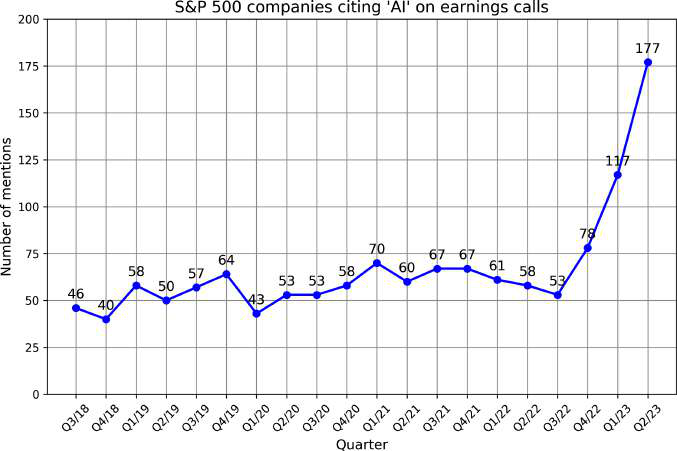

**Figure 1-5: AI mentions in S&P 500 earnings calls** - Enterprise attention to AI increased sharply after the ChatGPT moment.

[figure not shown]

**Figure 1-6: GitHub star growth of AI engineering tools** - Open-source AI engineering tools grew extremely fast compared with several well-known software projects.

## 6. Foundation-model use cases

The chapter surveys successful application patterns to show what foundation models are currently good at. The point is not that these are the only possible use cases, but that they reveal reusable patterns.

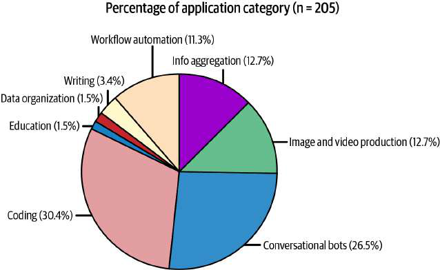

**Figure 1-7: Open-source AI use-case distribution** - The chapter categorizes 205 open-source AI applications across coding, media, writing, education, bots, aggregation, data organization, and automation.

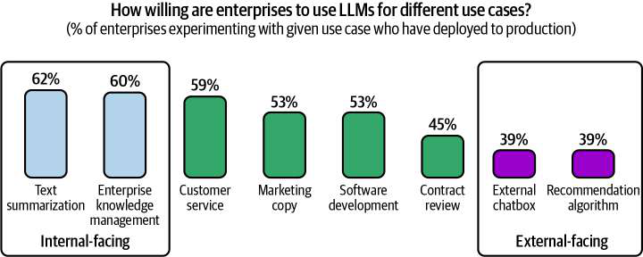

**Figure 1-8: Internal-facing enterprise AI** - Companies often start with internal applications because they reduce external risk while building organizational AI expertise.

| Use case | What AI is good at | Important caution |
| --- | --- | --- |
| **Coding** | Autocomplete, boilerplate, explaining code, frontend prototypes, test generation, simple refactors. | Complex backend logic, architecture, security, and production correctness still need strong engineering judgment. |
| **Image and video production** | Generating variations, marketing assets, concepts, edits, and visual prototypes. | IP, brand consistency, realism, and production-quality control can be hard. |
| **Writing** | Drafting, rewriting, summarizing, SEO variants, emails, product descriptions, and style transformations. | Generic writing can be low-value or untrustworthy without human taste and factual checks. |
| **Education** | Personalized tutoring, feedback, lesson variants, practice questions, and explanations. | Accuracy, age-appropriate behavior, learning design, and student dependency matter. |
| **Conversational bots** | Customer support, internal assistants, onboarding, roleplay, and interface simplification. | Quality bar depends on whether users see answers directly or through human review. |
| **Information aggregation** | Search, summarization, research assistance, document Q&A, market tracking. | Hallucinations and source quality are central risks. |
| **Data organization** | Classification, extraction, tagging, deduplication, transformation, cleanup. | Schema consistency and evaluation can be harder than the demo suggests. |
| **Workflow automation** | Automating multi-step business processes, routing, drafting, and tool use. | Failures compound across steps; monitoring and human-in-the-loop design become critical. |

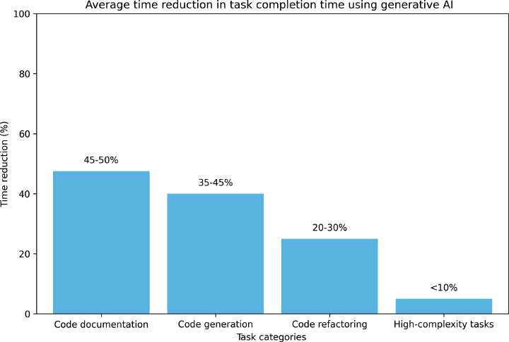

**Figure 1-9: Productivity impact by task complexity** - AI tends to help most on simpler tasks; complex tasks need more judgment, evaluation, and human oversight.

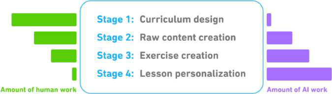

**Figure 1-10: AI in Duolingo course creation** - AI can support multiple stages of course creation, with personalization especially well-suited.

## 7. Planning AI applications

The chapter strongly warns that building a cool demo is much easier than creating a reliable, profitable product. Before building, ask whether AI is necessary, whether the use case matters, and whether you should build or buy.

### 7.1 Use-case evaluation: why build this?

| Reason to build | Priority level | Example |
| --- | --- | --- |
| AI threatens business continuity if ignored. | Highest | Document processing, financial analysis, insurance, creative production, aggregation businesses. |
| AI can boost profit or productivity. | High | Support automation, sales lead generation, marketing copy, research, internal communication. |
| The company is unsure but wants to learn. | Exploratory | R&D experiments, internal tooling, team upskilling. |

### 7.2 Role of AI in the product

| Dimension | Options | Engineering implication |
| --- | --- | --- |
| **Critical vs. complementary** | Does the product fail without AI, or is AI an enhancement? | The more critical AI is, the higher the reliability bar. |
| **Reactive vs. proactive** | Does AI respond to user action, or surface something without being asked? | Reactive features often need low latency; proactive features need especially high quality to avoid annoying users. |
| **Dynamic vs. static** | Does behavior update continuously from feedback or periodically with shared releases? | Dynamic systems need personalization, feedback loops, and stronger monitoring. |

### 7.3 Human-in-the-loop and Crawl-Walk-Run

Human involvement can change over time as the AI system improves:

- Crawl Human review is mandatory. AI drafts or suggests, but humans decide.
- Walk AI interacts directly with internal users or constrained workflows.
- Run AI handles more automation and may directly interact with external users.

A practical milestone might be: start with AI-suggested support replies, measure acceptance rate by human agents, then allow AI to answer simple tickets directly once quality is consistently high.

### 7.4 Defensibility: why will your AI product survive?

Foundation models lower the barrier to entry, which means they also lower the barrier for competitors. The chapter highlights three possible moats:

### Technology

Unique technical capability, model adaptation, system design, latency, reliability, or deep domain-specific implementation.

### Data

Usage data, proprietary datasets, customer feedback loops, and a data flywheel that improves the product over time.

### Distribution

Access to users, existing channels, brand, ecosystem integrations, partnerships, or workflow ownership.

### 7.5 Setting expectations

Success should be measured by business outcomes and usefulness thresholds, not just model vibes. For a customer-support chatbot, examples include automation rate, message throughput, response speed, labor saved, customer satisfaction, quality metrics, latency, cost per request, fairness, and interpretability.

### 7.6 Milestone planning and the last-mile challenge

**Demo trap:** The path from 0 to a cool demo can be fast. The path from demo to production quality can take months because each additional reliability gain becomes harder.

The chapter emphasizes that initial success can mislead teams. Off-the-shelf models may solve part of the problem immediately, but product-level reliability requires evaluation, hallucination handling, data work, prompt iteration, UX design, cost management, and monitoring.

### 7.7 Maintenance in a fast-moving ecosystem

AI product planning must include maintenance because models, prices, context lengths, APIs, laws, providers, and user expectations change quickly. The best option today can become a bad option tomorrow.

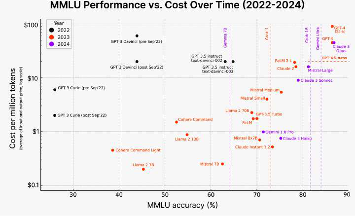

**Figure 1-11: Falling cost of AI reasoning** - The chapter emphasizes that model capability and inference cost are changing quickly, making maintenance and reevaluation essential.

| Change type | Example | How to prepare |
| --- | --- | --- |
| Model capability improves | Longer context windows, better reasoning, cheaper inference. | Keep evaluation suites and versioning so you can compare model swaps. |
| Provider/API changes | New APIs, pricing changes, provider shutdowns. | Use abstraction layers, fallbacks, and cost-benefit reviews. |
| Regulatory changes | Privacy, compute export controls, IP rules. | Design compliance review and avoid brittle assumptions about data rights. |

## 8. The AI engineering stack

The chapter breaks AI application building into three layers. You usually start from the application layer and move downward only when needed.

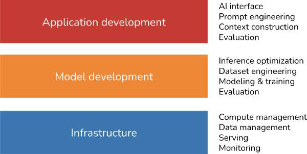

**Figure 1-14: Three-layer AI engineering stack** - The stack is application development, model development, and infrastructure.

| Layer | Responsibilities | Examples of work |
| --- | --- | --- |
| **Application development** | Build the user-facing AI application around available models. | Prompts, context, RAG, agents, interfaces, product flows, evaluation. |
| **Model development** | Develop or adapt the model itself. | Training, finetuning, dataset engineering, inference optimization, model evaluation. |
| **Infrastructure** | Run models and applications reliably at scale. | Serving, compute, data stores, monitoring, observability, orchestration, cost controls. |

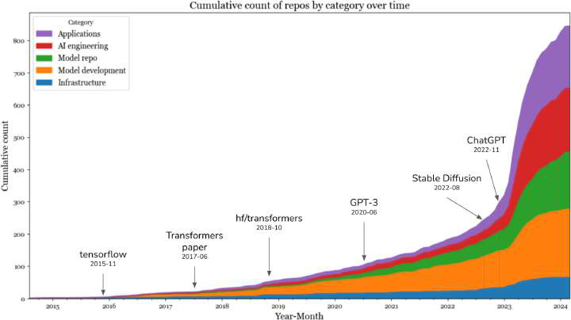

**Figure 1-15: AI repository categories over time** - Applications and application-development tooling grew especially quickly after Stable Diffusion and ChatGPT.

### 8.1 What stayed the same from ML engineering

- Applications still need to map business metrics to technical metrics.
- Systematic experimentation is still essential.
- Faster and cheaper inference still matters.
- Production feedback loops are still how systems improve.
- Evaluation is still central - now even more so because outputs are open-ended.

## 9. AI engineering vs. ML engineering vs. full-stack engineering

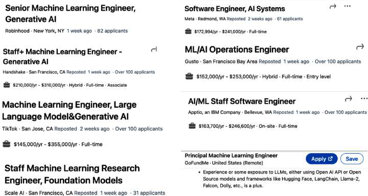

**Figure 1-12: AI and ML engineering under one umbrella** - Some organizations treat AI engineering as part of ML engineering.

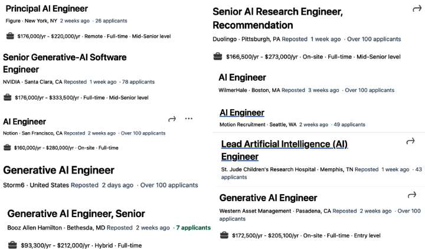

**Figure 1-13: Separate AI engineering roles** - Other organizations advertise AI engineering as a distinct role.

### 9.1 AI engineering vs. traditional ML engineering

| Category | Traditional ML engineering | AI engineering with foundation models |
| --- | --- | --- |
| **Starting point** | Collect data, train a model, then build application. | Start with an existing model, build product prototype, then invest in data/model work if promising. |
| **Main focus** | Modeling, training, feature engineering, deployment. | Model adaptation, prompting, context construction, evaluation, product integration. |
| **Output type** | Often fixed labels, scores, rankings, or structured predictions. | Often open-ended text, images, code, actions, or tool calls. |
| **Evaluation** | Important and often metric-driven. | Even harder because outputs are flexible, subjective, and sometimes non-deterministic. |
| **Compute scale** | Can range from small models to large systems. | Often involves very large models, GPUs, distributed inference, and cost/latency constraints. |

### 9.2 Prompt-based adaptation vs. finetuning

| Technique family | Changes model weights? | Pros | Cons |
| --- | --- | --- | --- |
| **Prompt-based techniques** | No | Fast to start, low data requirement, easy to iterate, works surprisingly well for many apps. | May not meet strict performance, latency, privacy, or complex behavior requirements. |
| **Finetuning** | Yes | Can improve quality, cost, latency, style consistency, and domain behavior. | Requires more data, more complexity, and stronger evaluation discipline. |

### 9.3 AI engineering vs. full-stack engineering

AI engineering is moving closer to full-stack engineering because foundation models allow developers to prototype useful applications before training custom models. Interfaces matter more now: standalone apps, browser extensions, Slack/Discord/WhatsApp bots, IDE plugins, product add-ons, voice interfaces, and embodied AR/VR experiences.

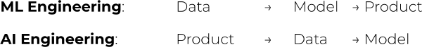

**Figure 1-16: New AI engineering workflow** - With foundation models available, teams can build product prototypes first, then invest deeper in data and model work after traction.

**Practical implication for builders:** Fast iteration is a real advantage. The AI engineer who can quickly prototype, collect feedback, evaluate outputs, and improve the system can beat a team that waits too long to do product validation.

## 10. Key review checklist

### Core tradeoffs

Build vs. buy, general-purpose vs. task-specific, prompt engineering vs. finetuning, internal vs. external use, reactive vs. proactive, demo quality vs. production quality.

### Production concerns

Evaluation, latency, cost, hallucinations, user feedback, maintenance, provider risk, regulation, IP, model swapping, monitoring, and data flywheels.

### One-paragraph chapter summary

Chapter 1 explains how the scaling of language models led to foundation models and then to AI engineering. Language models became powerful because self-supervision let them train on enormous amounts of text. As models expanded beyond text into multimodal data and became general-purpose, developers could build useful AI products without training models from scratch. This created a new workflow centered on adapting, evaluating, and deploying existing models through prompts, RAG, finetuning, interfaces, and infrastructure. The chapter also warns that AI product success requires more than a demo: teams must evaluate the use case, set measurable expectations, plan milestones, design human oversight, build defensibility, and maintain systems in a rapidly changing AI ecosystem.

**Source note:** These notes summarize Chapter 1 of *AI Engineering: Building Applications with Foundation Models* by Chip Huyen. Figures are included from the uploaded PDF for study context.